# Sales Forecasting and Economic Order Quantity Calculation of Pharmaceutical products

> Various pharmaceutical shops have a large number of expired medicines at the end of the month, which may go indisposed by the pharmacists or even if disposed, it leads to garbage production and wastage of the substances which could have been put to a better use.  
> Sales forecasting is an important aspect of operations management in any industry. This process involves the data analysis of the sales of the previous time and predict future sales. To answer the question as to what does the sales prediction signify, we can say that the expected demand of the products help us in predicting the sales of the product and thus prepare a planned budget and further take risk management measures.  
> Moving on to the significance of the demand, we can also calculate the EOQ (Economic Order Quantity) value which will also help in improving the company profits. Economic order quantity (EOQ) is a calculation, companies perform, that represents their ideal order size, allowing them to meet demand without overspending. Inventory managers calculate EOQ to minimize holding costs and excess inventory.

# 1. Introduction

Most commonly used method for sales prediction is Naïve model, where the forecasted values equal values in the previous period with added factor of growth, which is specifically defined for different regions, markets, categories of products, etc. This method is successful majorly for the large-scale businesses. But for the small-scale business this method fails to provide results with acceptable precision as they face significant random uncertainties in sales performance .

In below sections different methods and approaches related to sales time series data preparation, analysis and forecasting are validated, with aim to facilitate recommending sales of eight different groups of pharmaceutical products with diverse characteristics, such as stationarity, seasonality, amount of residuals and sales data variance. All these analyses and forecasts are made on a small scale, for a single distributor, pharmacy chain or even individual pharmacy. We have presented only univariate time series analysis. Effectiveness of Long-Short Term Memory (LSTM) neural networks was closely investigated.

Then in the next phase for the better inventory management practices we have also used the results of the sales prediction to calculate the EOQ for the inventory model of instantaneous replacement.

Every firm whether in service or manufacturing sector faces with two primary issues related with inventory: how much inventory to keep and when to replenish the stock. The accuracy of answers depends on preciseness of data collected related to number of items used, forecast of each item, variation in demand, resources available to manufacture items etc. Inventory models deals with such problems and provide answers to questions in such a manner so that total cost is most optimum.

In resolving the conflicting issue of keeping low inventories to reduce holding costs but high enough to reduce frequency of orders understanding of EOQ is important. This model as the title suggests calculates size of order that should be placed with supplier which would keep both cost of carrying it and placing new orders at most optimum. Inventory model of instantaneous replenishment is used to calculate EOQ and total inventory cost for 3 of the pharmaceutical products whose sales are predicted.

# 2. Theoretical background

Time series is a sequence of observations recorded at regular time intervals (hourly, daily, weekly, monthly, quarterly and yearly). Its analysis involves understanding various aspects of the time series, important for creating meaningful and accurate forecasts. Typically, a time-series data embodies each of the four different components:

1. level (mean of time-series data);
2. trend (long-term increasing or decreasing value in series);
3. seasonality (the repeating short-term cycle in the series); and
4. noise or residuals (random variations in the series).

One time-series can be assumed to be additive or multiplicative (although, in a real world, series that fit one or another model rarely exist). For additive series, time-dependent variable value is equal to the addition of four components, namely, y(t) = Level + Trend + Seasonality + Noise In multiplicative series, changes increase or decrease over time: y(t) = Level Trend Seasonality * Noise Each time-series can be decomposed to its four components, by using different methods, such as Naïve, Loess or STL. Decomposition is especially useful for trend and uncertainty (variance of residuals typically corresponds to randomness) analysis. Approximate or Sample Entropy methods can be used to quantify the regularity and predictability of fluctuations in a time series. The higher the entropies are, the more difficult is to forecast the time series. As difficulty increases, the time series converge to what is called – white noise, series of random numbers with mean equals 0.

## 2.1. Time series forecasting

Time series forecasting is the process of analysing time series data using statistics and modelling to make predictions and inform strategic decision-making. It’s not always an exact prediction, and likelihood of forecasts can vary wildly—especially when dealing with the commonly fluctuating variables in time series data as well as factors outside our control. However, forecasting insight about which outcomes are more likely—or less likely—to occur than other potential outcomes.

### 2.1.1. Neural networks

A good baseline forecast for a time series with a linear increasing trend is a persistence forecast. The persistence forecast is where the observation from the prior time step (t-1) is used to predict the observation at the current time step (t).

LSTM (Long Short-Term Memory) is a Recurrent Neural Network (RNN) based architecture that is widely used in natural language processing and time series forecasting.

The LSTM rectifies a huge issue that recurrent neural networks suffer from: short-memory. Using a series of ‘gates,’ each with its own RNN, the LSTM manages to keep, forget or ignore data points based on a probabilistic model.

After a prediction is made, it is fed back into the model to predict the next value in the sequence. With each prediction, some error is introduced into the model. To avoid exploding gradients, values are ‘squashed’ via (typically) sigmoid & tanh activation functions prior to gate entrance & output.

[figure not shown]

## 2.2. Instantaneous Replenishment model: EOQ

There are various assumptions taken up before making the calculations. Assumptions are listed below:

1. Demand rate is constant: the inclined line in the figure (Fig. 1) indicates that daily demand out of stock of 50 units is constant of 10 units. Thus units are consumed at fixed, constant rate.
2. Size of each lot is constant: in every ordering cycle number of units ordered is same. It also implies that there are no constraints in production. A supplier can always without any bottlenecks would be able to provide a fixed batch size of Q.
3. The model takes into consideration only holding and ordering costs.
4. Reorder point is constant: Every order in each ordering cycle is placed at same time or when same number of units is left in the stock. For instance, a batch size of 50 units, daily demand of 10 units and lead time of 2 days implies that next order should be placed when 2*10=20 units are left in the stock. So, in case of every ordering cycle next order would be place after 3 days or when 20 units are left in the stock as shown in Fig. 1.
5. Lead time is fixed and constant. Supplier would provide a fixed batch size in fixed and certain time period.
6. Model should be applied only for those items whose demand is independent of other items.
7. One of the most important assumptions of EOQ model is that stock gets replaced instantaneously that is why the model is also called as instantaneous replenishment model.

[figure not shown]

# 3. Methodology

The methodology for implementing sales prediction on the datasets follows the typical time series forecasting pipeline, consisting of three major phases:

1. feature engineering and data preparation;
2. exploratory data analysis (time-series analysis); and
3. forecasting.

With the understanding of above-mentioned assumptions of EOQ following procedure is adopted for formulating the quantitative formula for calculating number of units to be ordered per batch and total cost. As discussed, total cost would be a function of only ordering and holding cost. Notations used in the model are: D: Annual demand H: Holding cost per unit S: Ordering or set-up cost per order Q: Batch size

Holding cost: Between time period of start and end of cycle (time period t) on an average at any particular unit Q/2 units are being held up in inventory. As Fig below shows, with increase in number of units stored in inventory annual holding cost increases. If to hold one unit holding cost is H then: Annual holding cost = Average inventory level *Holding cost per unit = (Q/2)* H

Ordering cost: Suppose annual demand of an item is 1000 units and manager orders 100 units per order. Thus he/she has to place an order 10 times. Thus (D/Q) represents number of orders. As Fig below shows, with increase in number of units stored in inventory annual ordering cost decreases. If S is set up or ordering cost per order then: Annual ordering cost = Number of orders per year *Ordering or set up cost per order = (D/Q)* S

Figure below deduces a very important relationship between holding and ordering cost. The graph clearly shows that as number of units stored increase holding cost keeps on increasing and ordering cost decreases. This is quite understandable as with bigger batch size frequency of repeating orders automatically decreases.

Thus ordering and holding cost have an inverse relationship with each other. Importantly, the intersection of holding and ordering cost curve indicates number of units that should be ordered per batch. At this intersection point the most optimum total annual cost can be computed.

[figure not shown]

As total cost is a combination of two types of cost so: Total cost = Annual holding cost + Annual ordering cost TC = (Q/2) *H + (D/Q)* S

To find minimum possible cost the above equation is differentiated w.r.t. Q and simple minima calculus is applied to find out batch size Q which would be Q = √(2DS/H)

This formula of Q would provide manager the most optimum batch size that should be ordered with minimum total annual cost.

# 4. Dataset Preperation

Initial dataset consisted of 600000 transactional data collected in 6 years (period 2014-2019), indicating date and time of sale, pharmaceutical drug brand name and sold quantity. The selected group of drugs (57 drugs) for analysis is classified to 8 Anatomical Therapeutic Chemical (ATC) Classification System categories: • M01AB - Anti-inflammatory and antirheumatic products, non-steroids, Acetic acid derivatives and related substances • M01AE - Anti-inflammatory and antirheumatic products, non-steroids, Propionic acid derivatives • N02BA - Other analgesics and antipyretics, Salicylic acid and derivatives • N02BE/B - Other analgesics and antipyretics, Pyrazolones and Anilides • N05B - Psycholeptics drugs, Anxiolytic drugs • N05C - Psycholeptics drugs, Hypnotics and sedatives drugs • R03 - Drugs for obstructive airway diseases • R06 - Antihistamines for systemic use

[figure not shown]

We have utilized the final datasets which have been cleaned and modelled for analysis.

# 5. Data Analysis

Time Series Analysis included seasonality, stationarity, autocorrelation and regularity analysis.

## 5.1 Seasonality analysis

The seasonality patterns can be explored in detail by using boxplots. Seasonality is clearly confirmed for the categories of R03, R06 and N02BE. Some additional conclusions: R03 and N05C has more outliers that the others, indicating that their sales is more difficult to predict.

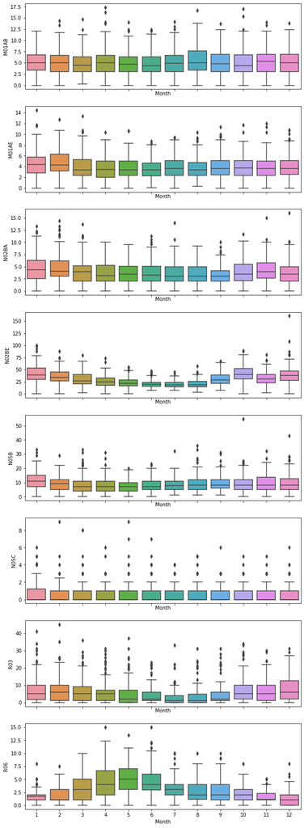

Below, boxplots on a weekly scale are shown, for the purpose of exploring the weakly seasonality. Some weekly seasonality is visible.

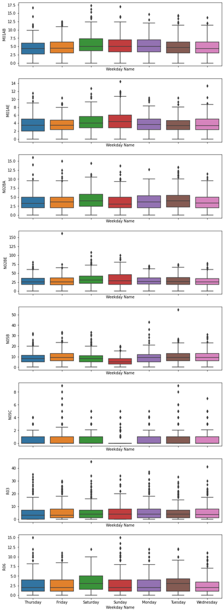

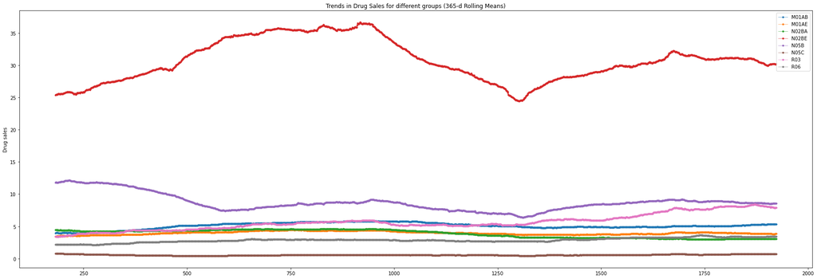

## 5.2 Stationarity analysis

Stationarity of time-series is the property of exhibiting constant statistical properties over time (for example, mean, variance, autocorrelation). In stationary time series, the mean of the series, variance of the series and covariance of the i th term and the (i + m) th term should not be a function of time. We can use Augmented Dickey-Fuller (ADF) test to check stationarity of the data. Possible values of regression parameters of ADF are:

1. c : constant only (default)
2. ct : constant and trend
3. ctt : constant, and linear and quadratic trend
4. nc : no constant, no trend

```
ADF test for M01AB
-----------------------------
Test statistic = -3.700
P-value = 0.022
Critical values :
	1%: -3.9897903649837616 - The data is not stationary with 99% confidence
	5%: -3.425478311521626 - The data is  stationary with 95% confidence
	10%: -3.1358607194990724 - The data is  stationary with 90% confidence
ADF test for M01AE
-----------------------------
Test statistic = -8.717
P-value = 0.000
Critical values :
	1%: -3.98926783537037 - The data is  stationary with 99% confidence
	5%: -3.425226747185185 - The data is  stationary with 95% confidence
	10%: -3.1357131066666666 - The data is  stationary with 90% confidence
ADF test for N02BA
-----------------------------
Test statistic = -2.670
P-value = 0.249
Critical values :
	1%: -3.990441532957606 - The data is not stationary with 99% confidence
	5%: -3.425791763669738 - The data is not stationary with 95% confidence
	10%: -3.1360446341572343 - The data is not stationary with 90% confidence
ADF test for N02BE
-----------------------------
Test statistic = -4.362
P-value = 0.003
Critical values :
	1%: -3.98926783537037 - The data is  stationary with 99% confidence
	5%: -3.425226747185185 - The data is  stationary with 95% confidence
	10%: -3.1357131066666666 - The data is  stationary with 90% confidence
ADF test for N05B
-----------------------------
Test statistic = -3.782
P-value = 0.018
Critical values :
	1%: -3.9895792190177497 - The data is not stationary with 99% confidence
	5%: -3.4253766620686186 - The data is  stationary with 95% confidence
	10%: -3.135801074760346 - The data is  stationary with 90% confidence
```

[output cut: 9 more lines]

```
-----------------------------
Test statistic = -3.806
P-value = 0.016
Critical values :
	1%: -3.9898970270434053 - The data is not stationary with 99% confidence
	5%: -3.4255296586298916 - The data is  stationary with 95% confidence
	10%: -3.1358908478232332 - The data is  stationary with 90% confidence
ADF test for R06
-----------------------------
Test statistic = -5.258
P-value = 0.000
Critical values :
	1%: -3.9906647072202452 - The data is  stationary with 99% confidence
	5%: -3.4258991818227846 - The data is  stationary with 95% confidence
	10%: -3.1361076573601 - The data is  stationary with 90% confidence
```

## 5.3 Regularity analysis

```
M01AB: 1.141130089570642
M01AE: 1.166363924596575
N02BA: 1.1370638730125302
N02BE: 1.058024809082593
N05B: 1.074437415034502
N05C: 1.0361887401424648
R03: 1.1847216239035152
R06: 1.031759595747876
```

## 5.4 Autocorrelation analysis

Autocorrelation analysis illustrates the potential for time series data prediction. Autocorrelation plots graphically summarize the strength of a relationship with an observation in a time series with observations at prior time steps. Pearson coefficient is used to measure autocorrelation. Thus, the following analysis is relevant only for data with normal Gaussian distribution.

A plot of the autocorrelation of a time series by lag is called the AutoCorrelation Function (ACF). This plot is sometimes called a correlogram or an autocorrelation plot. Plot shows the lag value along the x-axis and the correlation on the y-axis between -1 and 1. Confidence intervals are drawn as a cone. By default, this is set to a 95% confidence interval, suggesting that correlation values outside of this code are very likely a correlation.

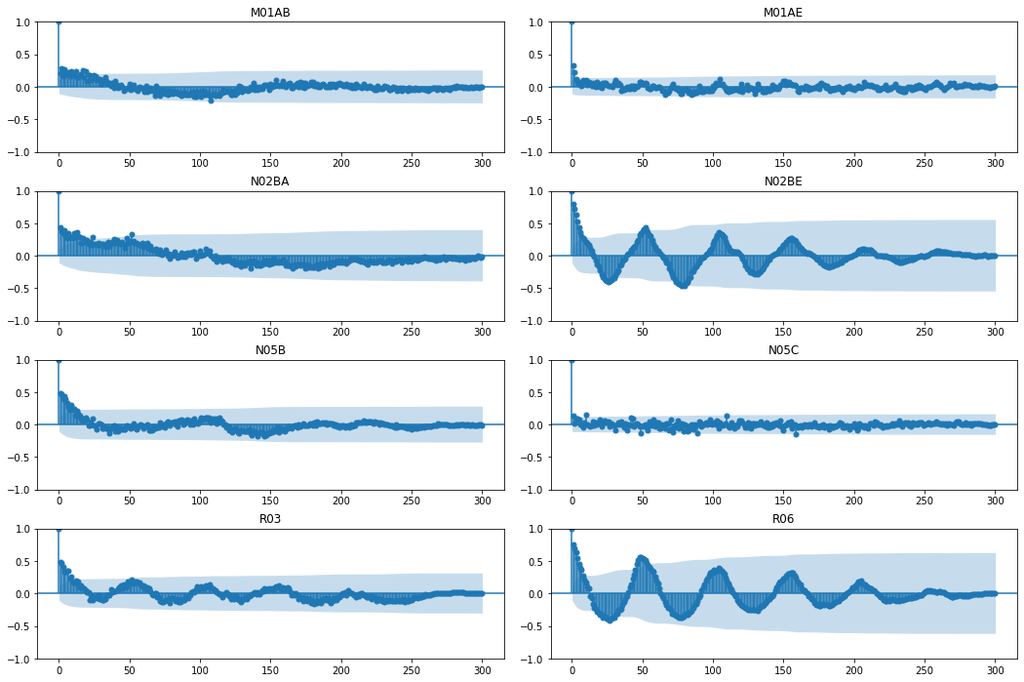

In general, the "partial" correlation between two variables is the amount of correlation between them which is not explained by their mutual correlations with a specified set of other variables. For example, if we are regressing a variable Y on other variables X1, X2, and X3, the partial correlation between Y and X3 is the amount of correlation between Y and X3 that is not explained by their common correlations with X1 and X2.

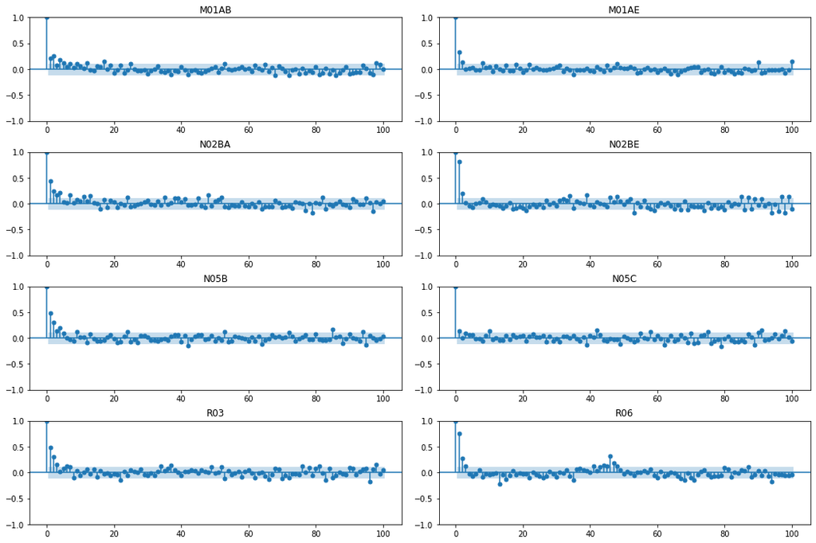

Minor autocorrelation is observed at ACF (Auto-Correlation Function) and PACF (Partial Auto-Correlation Function) plots for all series, with exception of N05C sales. N02BE, R03 and R06 series were found to exhibit annual seasonality.

# 6. Sales forecasting

Forecasting models were fitted with weekly time-series data with dataset of 302 rows. LSTM forecasting method was tested. Train-test split method was used (52 weeks of test data). MSE was used as metrics for comparing the performance and also as a loss function for LSTM. Mean Absolute Percentage Error (MAPE) is also measured. Average method was used as a baseline for long-term forecasting, while Naïve and Seasonal Naïve were used for rolling forecasts.

Forecasting results are validated by using two approaches: short-term and long-term forecasts. For short-term forecasts (or so-called rolling-forecast) validation or walk-forward model validation, train-test split validation is performed in iterative fashion, where observations are added to the training dataset after every individual weekly sales prediction, while the model is fitted in each iteration. Therefore, during testing, prediction in a timestep t is based on the model which fits the training set consisting of observations in timesteps (0,t-1), or: f(t) = f(o[0:t-1]). Long-term forecasts validation is based on MSE of one-year forecast, compared to actual observations.

All MSE metrics will be stored in a dataframe, which will be later use for presentation of the overall results and comparison.

## 6.1 Baseline forecasting accuracy

### 6.1.1 Naïve forecasting

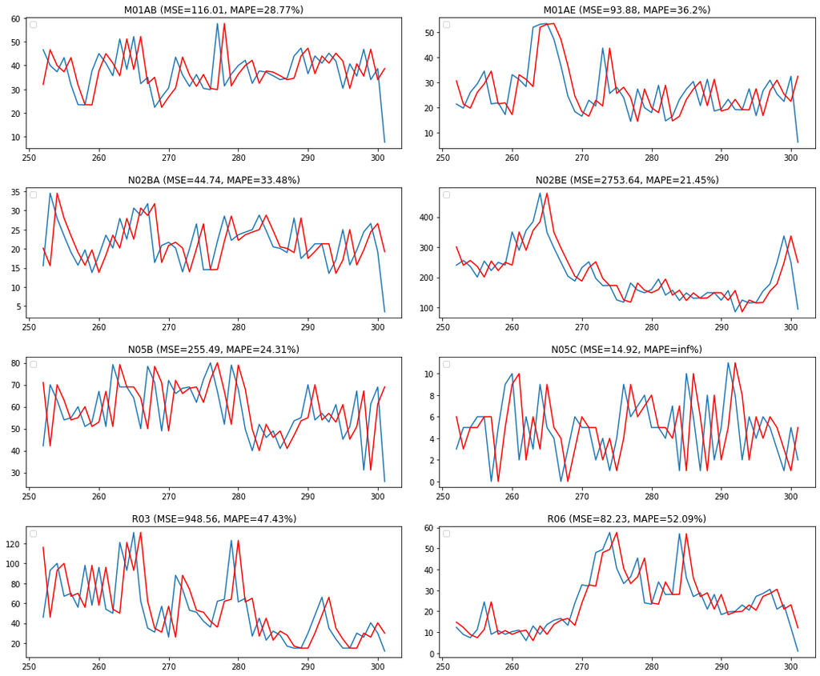

### 6.1.2 Average method forecasting

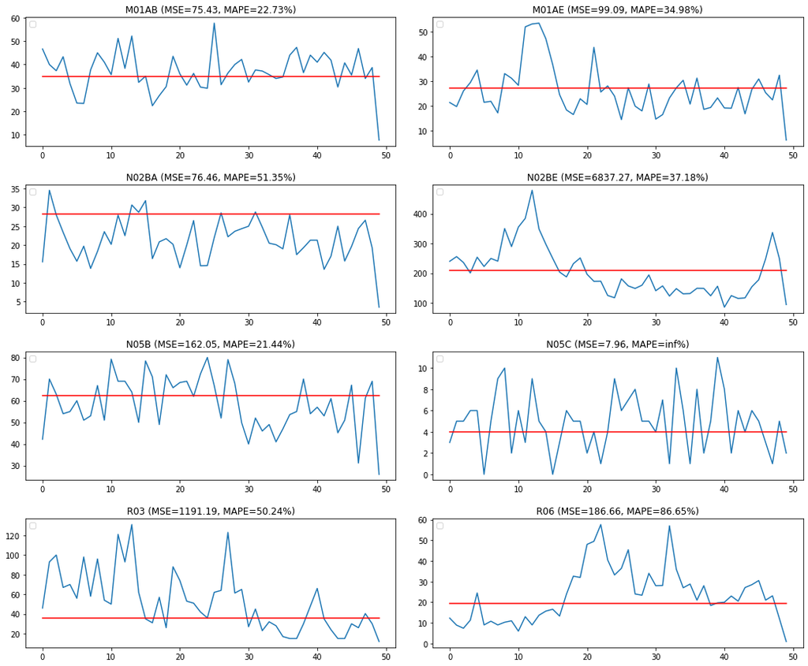

### 6.1.3 Seasonal Naïve forecasting

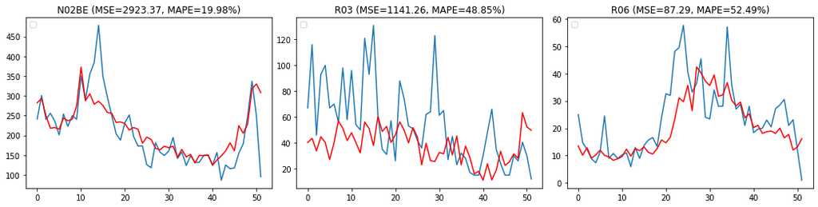

## 6.2 Forecasting with LSTM

Long-term forecasting validation has been done with three LSTM configurations: Vanilla LSTM, Stacked LSTM and Bi-directional LSTM. Relu activation function was used, optimizer was Adam and loss function was Mean Squared Error. The best results were achieved with training the model in 400 epochs. Before fitting, all data was standardized (rescaled in interval -1,1) and transformed to data for supervised problem.

Number of past observations tested in input sequences was either 10 or 5. For series with larger variances and randomness (N05B and N05C) and simpler, Vanilla LSTM model, 10 past observations produced better forecasting accuracy. In all other cases, 5 past observations were used. This is the parameter that has been adopted.

### 6.2.1 Long-term forecasting with Vanilla LSTM configuration

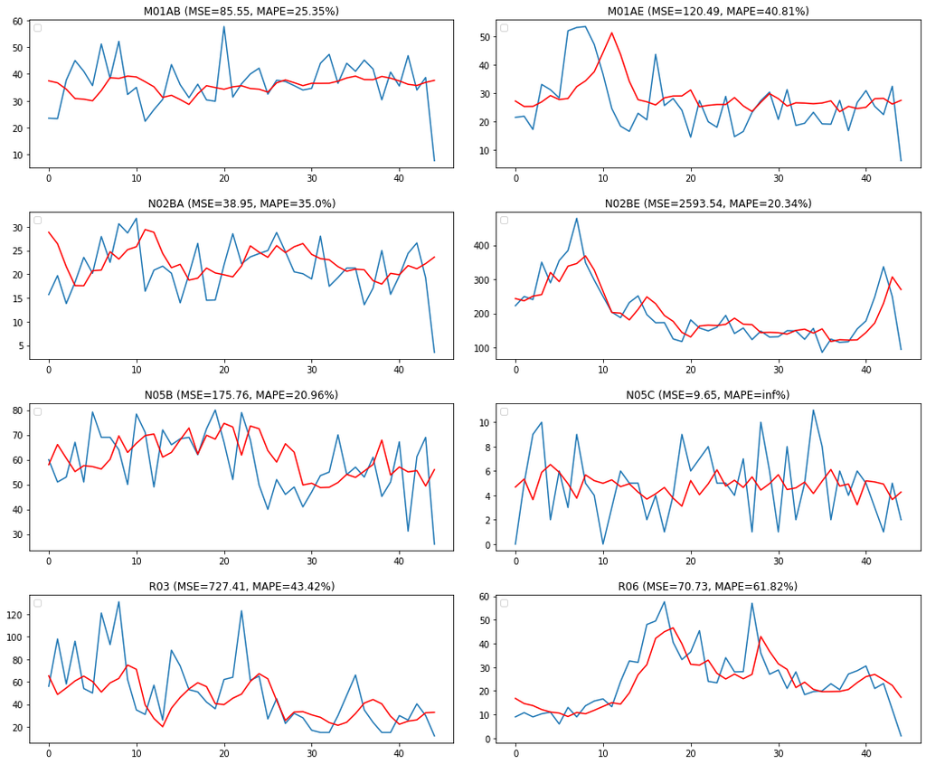

### 6.2.2. Long-term forecasting with Stacked LSTM model

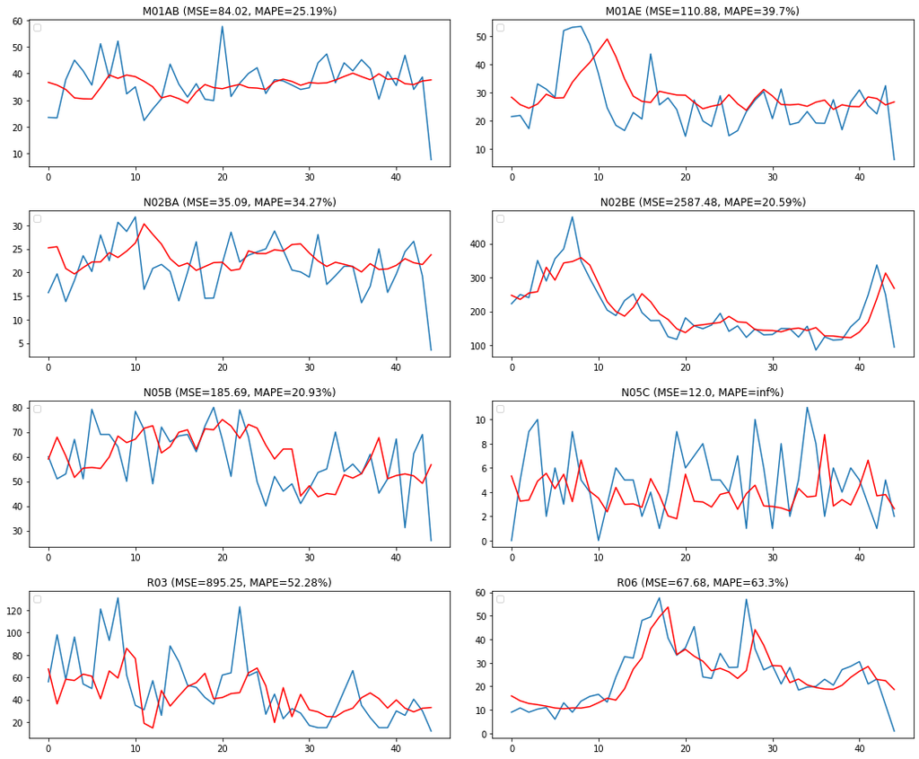

### 6.2.3 Long-term forecasting with Bidirectional LSTM

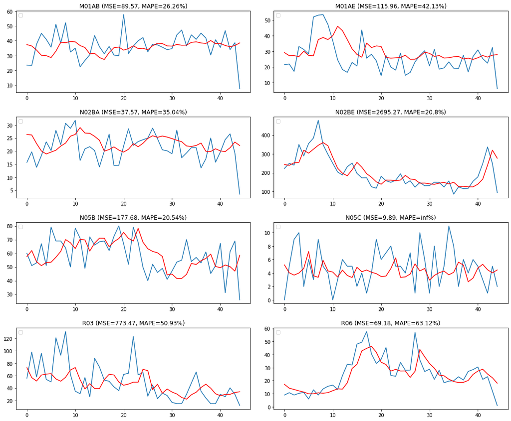

# 7. Forecast Result and Observation

The sales prediction results are given below. These are the units count which are estimated to be sold according to the sales pattern of the datasets.

|  | M01AB | M01AE | N02BA | N02BE | N05B | N05C | R03 | R06 |
| --- | --- | --- | --- | --- | --- | --- | --- | --- |
| Average | 34.710266 | 27.342229 | 28.171266 | 209.240919 | 62.360863 | 3.987930 | 35.603629 | 19.550585 |
| Vanilla LSTM | 37.623108 | 27.534327 | 23.610294 | 269.950317 | 55.982811 | 4.271245 | 32.908825 | 17.261889 |
| Stacked LSTM | 37.602489 | 26.731209 | 23.761332 | 268.016632 | 56.733463 | 2.629960 | 32.981384 | 18.660324 |
| Bidirectional LSTM | 38.539761 | 27.962538 | 22.111977 | 277.060028 | 58.575012 | 4.447941 | 34.097073 | 18.091780 |

For rolling forecasting Naive and Seasonal Naive forecast methods perform deficiently and thus other methods such as ARIMA method must be tried.

|  | M01AB | M01AE | N02BA | N02BE | N05B | N05C | R03 | R06 |
| --- | --- | --- | --- | --- | --- | --- | --- | --- |
| Naive MSE | 116.014866 | 93.875126 | 44.741150 | 2753.643864 | 255.485600 | 14.92 | 948.560347 | 82.228700 |
| Naive MAPE | 28.765667 | 36.202952 | 33.475848 | 21.451644 | 24.308687 | inf | 47.432638 | 52.094536 |
| Seasonal Naive MSE | 0.000000 | 0.000000 | 0.000000 | 2923.370345 | 0.000000 | 0.00 | 1141.258975 | 87.288057 |
| Seasonal Naive MAPE | 0.000000 | 0.000000 | 0.000000 | 19.976880 | 0.000000 | 0.00 | 48.845563 | 52.491895 |

For long-term forecasting, LSTM models have shown significantly better performance then benchmarks (Naïve and seasonal Naïve) in the time series with seasonality. In all cases, even without optimization, LSTM models have achieved competitive performance.

|  | M01AB | M01AE | N02BA | N02BE | N05B | N05C | R03 | R06 |
| --- | --- | --- | --- | --- | --- | --- | --- | --- |
| Average MSE | 75.428945 | 99.086133 | 76.460997 | 6837.269559 | 162.050944 | 7.961872 | 1191.186483 | 186.661004 |
| Average MAPE | 22.727171 | 34.980731 | 51.351070 | 37.175660 | 21.443035 | inf | 50.243843 | 86.645469 |
| Vanilla LSTM MSE | 85.546344 | 120.485749 | 38.945378 | 2593.544288 | 175.758132 | 9.645553 | 727.408924 | 70.734269 |
| Vanilla LSTM MAPE | 25.349667 | 40.807803 | 34.996276 | 20.338070 | 20.958004 | inf | 43.421212 | 61.815018 |
| Stacked LSTM MSE | 84.016034 | 110.882295 | 35.093757 | 2587.475178 | 185.690265 | 12.001603 | 895.251478 | 67.677445 |
| Stacked LSTM MAPE | 25.185488 | 39.701109 | 34.265798 | 20.592866 | 20.931062 | inf | 52.279368 | 63.299131 |
| Bidirectional LSTM MSE | 89.568805 | 115.956529 | 37.569835 | 2695.269753 | 177.675019 | 9.888824 | 773.467168 | 69.184471 |
| Bidirectional LSTM MAPE | 26.255504 | 42.128107 | 35.037397 | 20.803967 | 20.537927 | inf | 50.928509 | 63.118159 |

To conclude, time-series analyses and forecasts have guided potentially useful conclusions and recommendations to the pharmacy. Daily, weekly and annual seasonality analysis were proven useful for identifying the periods in which special sales and marketing campaigns could be implemented, except for N05B and N05C categories of drugs which did not exhibit significant regularities. Forecasts have proven better than Naïve methods and in acceptable intervals for long-term planning. It is highly likely that the forecasts could be significantly improved by expanding the problem scope to multivariate time series forecasting and by including explanatory variables.

# 8. EOQ and Total Inventory Cost Calculation

Holding cost (Ch): also termed as carrying cost is the cost associated with holding inventory in hand. They include storage costs, spoilage costs, obsolescence costs etc. For instance a warehouse storing grains has to spend money on its maintenance and prevent it from getting spoiled. Thus such awarehouse incurs much of its expenditure in holding grains.

Ordering cost (Co): also termed as set-up cost are incurred on obtaining additional inventories. They include costs of communicating new order, transportation costs etc. In manufacturing when machine has to stop for replacement of tools to produce different item then time is lost in production because of setting up of process. That is why this cost is also called as set-up cost.

|  | M01AB | N02BA | R03 | Co (M01AB) | Co (N02BA) | Co (R03) | Ch (M01AB) | Ch (N02BA) | Ch (R03) |
| --- | --- | --- | --- | --- | --- | --- | --- | --- | --- |
| Average | 34.710266 | 28.171266 | 35.603629 | 450.0 | 350.0 | 400.0 | 15.0 | 5.0 | 10.0 |
| Vanilla LSTM | 37.623108 | 23.610294 | 32.908825 | 450.0 | 350.0 | 400.0 | 15.0 | 5.0 | 10.0 |
| Stacked LSTM | 37.602489 | 23.761332 | 32.981384 | 450.0 | 350.0 | 400.0 | 15.0 | 5.0 | 10.0 |
| Bidirectional LSTM | 38.539761 | 22.111977 | 34.097073 | 450.0 | 350.0 | 400.0 | 15.0 | 5.0 | 10.0 |

EOQ predicted are units to be ordered and total inventory cost is optimized cost that will be required to maintain the inventory.

|  | EOQ (M01AB) | EOQ (N02BA) | EOQ (R03) | Tc (M01AB) | Tc (N02BA) | Tc (R03) |
| --- | --- | --- | --- | --- | --- | --- |
| Average | 45 | 62 | 53 | 684.535312 | 314.005463 | 533.693765 |
| Vanilla LSTM | 47 | 57 | 51 | 712.679421 | 287.464833 | 513.099015 |
| Stacked LSTM | 47 | 57 | 51 | 712.484111 | 288.382837 | 513.664359 |
| Bidirectional LSTM | 48 | 55 | 52 | 721.309065 | 278.194030 | 522.280175 |